# 1.Introduction

1. The 'adult_raw' dataset contains demographic information about individuals, including attributes such as age, education, marital status, occupation, relationship, race, gender, native country, and income. My goal is to analyze the relations between such features.
2. The address to access this dataset is 'https://archive.ics.uci.edu/dataset/2/adult', which was created by Barry Becker and Ronny Kohavi in UC Irvine.

```python
#prepare tools for analysis
import pandas as pd
import numpy as np
import seaborn as sns
import matplotlib.pyplot as plt
```

```python
#import the data and prepare it for analysis
adult_raw=pd.read_csv('adult.data')
adult_raw.columns = ['age', 'workclass', 'fnlwgt', 'education', 'education_num', 'marital_status', 'occupation', 'relationship', 'race','sex', 'capital_gain',
                 'capital_loss', 'hours_per_week', 'native_country', 'income']
num_rows, num_columns = adult_raw.shape
print("Number of rows:", num_rows)
print("Number of columns:", num_columns)
adult_raw.head()
```

```
Number of rows: 32560
Number of columns: 15
```

|  | age | workclass | fnlwgt | education | education_num | marital_status | occupation | relationship | race | sex | capital_gain | capital_loss | hours_per_week | native_country | income |
| --- | --- | --- | --- | --- | --- | --- | --- | --- | --- | --- | --- | --- | --- | --- | --- |
| 0 | 50 | Self-emp-not-inc | 83311 | Bachelors | 13 | Married-civ-spouse | Exec-managerial | Husband | White | Male | 0 | 0 | 13 | United-States | <=50K |
| 1 | 38 | Private | 215646 | HS-grad | 9 | Divorced | Handlers-cleaners | Not-in-family | White | Male | 0 | 0 | 40 | United-States | <=50K |
| 2 | 53 | Private | 234721 | 11th | 7 | Married-civ-spouse | Handlers-cleaners | Husband | Black | Male | 0 | 0 | 40 | United-States | <=50K |
| 3 | 28 | Private | 338409 | Bachelors | 13 | Married-civ-spouse | Prof-specialty | Wife | Black | Female | 0 | 0 | 40 | Cuba | <=50K |
| 4 | 37 | Private | 284582 | Masters | 14 | Married-civ-spouse | Exec-managerial | Wife | White | Female | 0 | 0 | 40 | United-States | <=50K |

# 2.Preprocessing

1. Adjust the dataset to prepare the data for analysis. *
2. Remove any columns that are not meaningful or otherwise of interest.
3. Detect missing values and, if any are found, remove or replace them.
4. Perform an outlier analysis on all quantitative columns.

```python
#remove rows with missing values
adult_raw.dropna(inplace=True)
#remove columns that are not useful or not interesting for analysis
adult = adult_raw[['age', 'workclass', 'education', 'education_num', 'occupation', 'capital_gain','capital_loss','hours_per_week', 'native_country', 'income']]
print(adult.shape)
adult.head()
```

```
(32560, 10)
```

|  | age | workclass | education | education_num | occupation | capital_gain | capital_loss | hours_per_week | native_country | income |
| --- | --- | --- | --- | --- | --- | --- | --- | --- | --- | --- |
| 0 | 50 | Self-emp-not-inc | Bachelors | 13 | Exec-managerial | 0 | 0 | 13 | United-States | <=50K |
| 1 | 38 | Private | HS-grad | 9 | Handlers-cleaners | 0 | 0 | 40 | United-States | <=50K |
| 2 | 53 | Private | 11th | 7 | Handlers-cleaners | 0 | 0 | 40 | United-States | <=50K |
| 3 | 28 | Private | Bachelors | 13 | Prof-specialty | 0 | 0 | 40 | Cuba | <=50K |
| 4 | 37 | Private | Masters | 14 | Exec-managerial | 0 | 0 | 40 | United-States | <=50K |

```
age                143
education_num     1198
capital_gain      2711
capital_loss      1519
hours_per_week    9008
dtype: int64
```

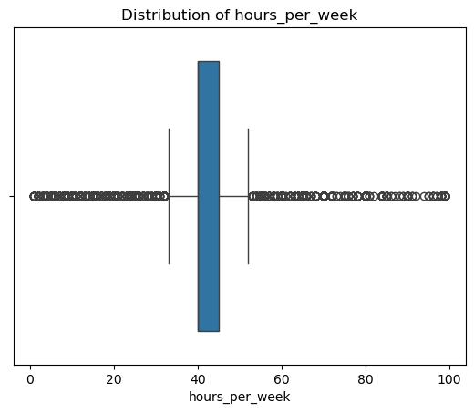

```python
# Convert columns to numeric
adult_quant = adult[['age', 'education_num','capital_gain', 'capital_loss', 'hours_per_week']].apply(pd.to_numeric)
# Perform outlier detection
def is_outlier(x):
    Q25, Q75 = x.quantile([.25,.75])
    I = Q75 - Q25
    return (x < Q25 - 1.5*I) |  (x > Q75 + 1.5*I)
outliers = adult_quant.apply(is_outlier)
print(outliers.sum())
outliers_sum = outliers.sum()
#To find out the reason why there are so many outliers in hours_per_week, we can use a boxplot to visualize the distribution of hours_per_week
sns.boxplot(x=adult_quant['hours_per_week'])
plt.xlabel('hours_per_week')
plt.title('Distribution of hours_per_week')
plt.show()
```

# 3 Summary Data Analysis

1. Make a statistical summary of every column using numerical and graphical components.
2. Explore correlations between quantitative columns.

```
                age  education_num  capital_gain  capital_loss  hours_per_week
count  32560.000000   32560.000000  32560.000000  32560.000000    32560.000000
mean      38.581634      10.080590   1077.615172     87.306511       40.437469
std       13.640642       2.572709   7385.402999    402.966116       12.347618
min       17.000000       1.000000      0.000000      0.000000        1.000000
25%       28.000000       9.000000      0.000000      0.000000       40.000000
50%       37.000000      10.000000      0.000000      0.000000       40.000000
75%       48.000000      12.000000      0.000000      0.000000       45.000000
max       90.000000      16.000000  99999.000000   4356.000000       99.000000


       age  education_num  capital_gain  capital_loss  hours_per_week
0.25  28.0            9.0           0.0           0.0            40.0
0.50  37.0           10.0           0.0           0.0            40.0
0.75  48.0           12.0           0.0           0.0            45.0
```

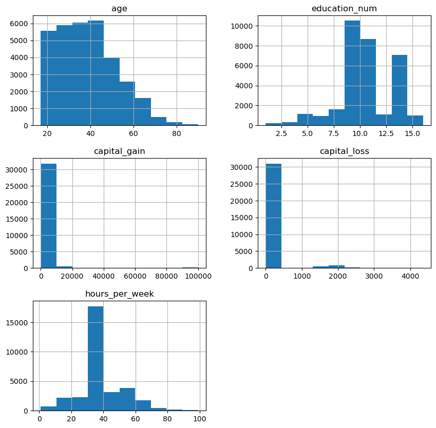

```python
# Numerical summary
summary = adult.describe()
quantiles = adult_quant.quantile([0.25, 0.5, 0.75])
print(summary)
print('\n')
print(quantiles, '\n')



# Graphical summary
adult.hist(figsize=(10, 10))
plt.show()
```

```
                     age  education_num  capital_gain  capital_loss  \
age             1.000000       0.036527      0.077674      0.057775
education_num   0.036527       1.000000      0.122627      0.079932
capital_gain    0.077674       0.122627      1.000000     -0.031614
capital_loss    0.057775       0.079932     -0.031614      1.000000
hours_per_week  0.068756       0.148127      0.078409      0.054256

                hours_per_week
age                   0.068756
education_num         0.148127
capital_gain          0.078409
capital_loss          0.054256
hours_per_week        1.000000
```

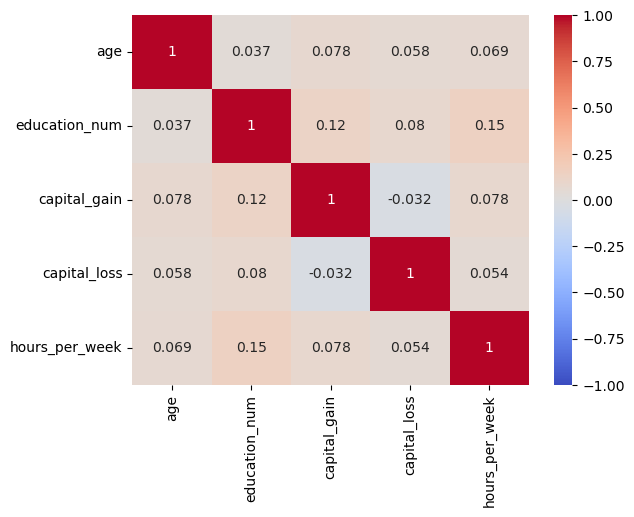

```python
#Explore correlations between quantitative columns numerically
correlation = adult_quant.corr()
sns.heatmap(correlation, annot=True, cmap='coolwarm',vmin=-1, vmax=1)
print(correlation)
```

# 4.Discussion

### 1.Prediction of a categorical outcome

Do age, education_num, capital_gain, capital_loss and hours_per_week predict whether an individual's income exceeds 50K?

Rationale: Based on the previous analysis, we can find the correlations between quantitative columns and use such relation to predict the categorical column 'income' to find the greater probability between {income is bigger than 50K, income is less than 50K} and thus predict whether an individual's income exceeds 50K

### 2.Prediction of a quantitative outcome

Can we use education_num, hours_per_week, occupation, workclass along with capital_gain and capital_loss to predict an individual's age ?

Rationale: 'age' is a quantitative column. With the heatmap of correlations, we can use other quantitative columns to predict that specific quantitative column